# Generalized Jeffreys’s Approximate Objective Bayes Factor

## 4B. Table $4\times5$ (`indepMulti`)

Visualization (Fixed Row Sums)

### Boxplot ($\ln\textit{BF}_{01}$)

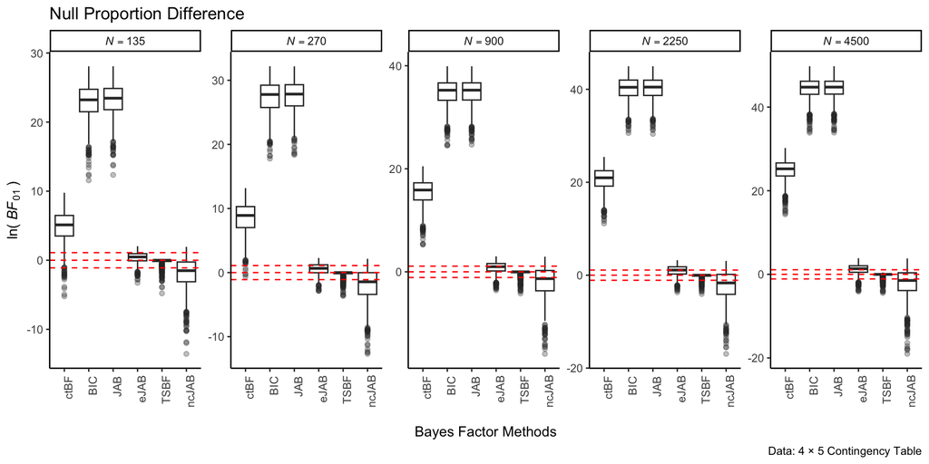

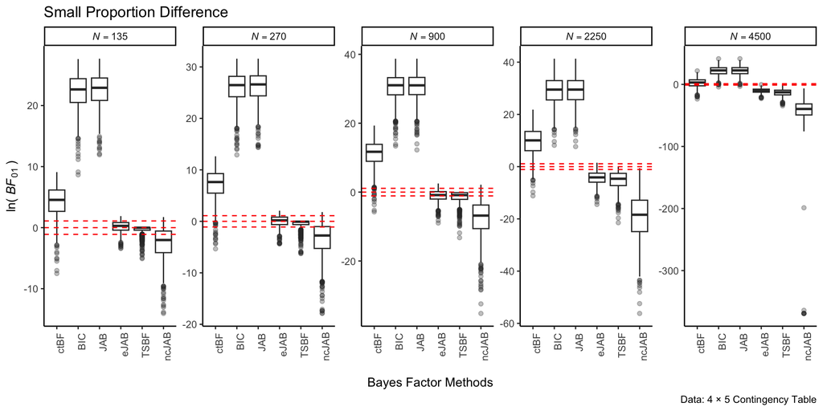

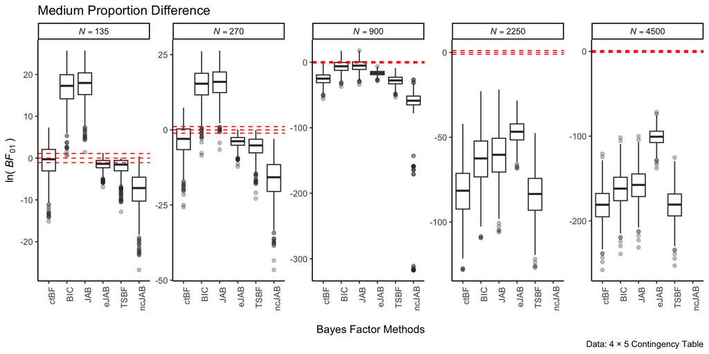

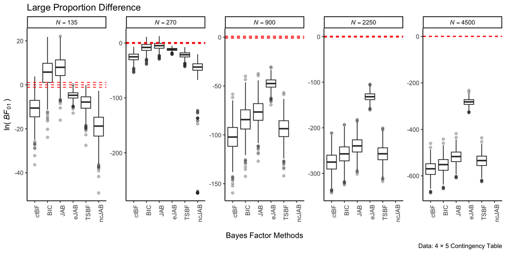

When simulated under the alternative, some methods produce extremely small values supporting the null, which are rounded down to zero. This results in their log values being reported as negative infinity, and consequently, no boxes are shown in the figure.

scroll to top

### Boxplot (Percent Errors)

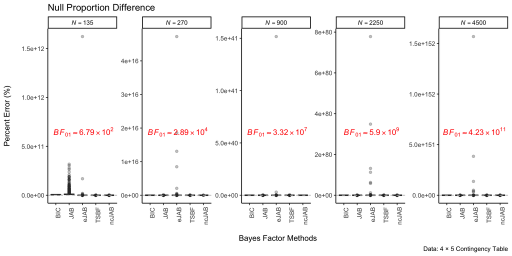

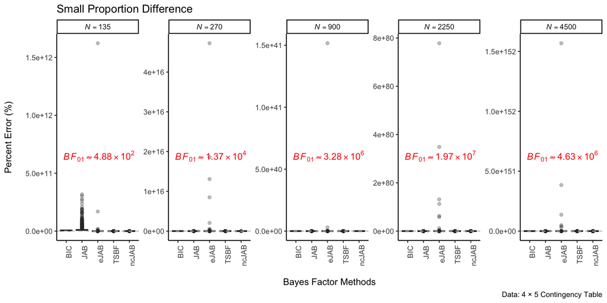

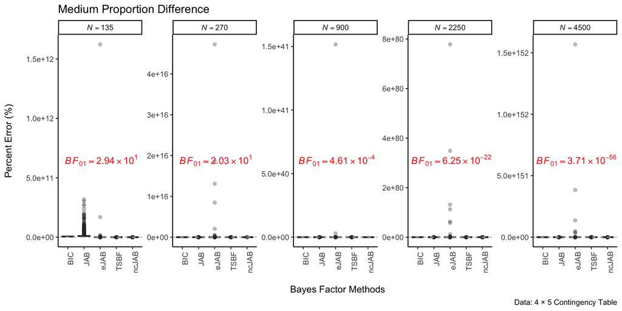

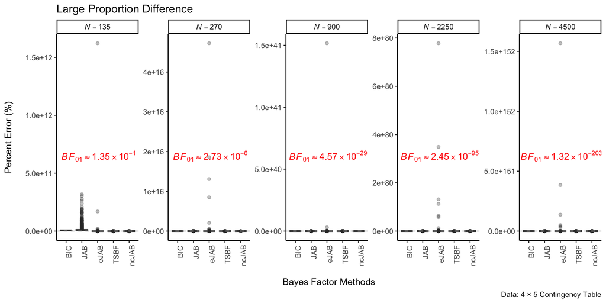

scroll to top

### Line Chart (Proportions of Agreement)

[interactive chart not shown]

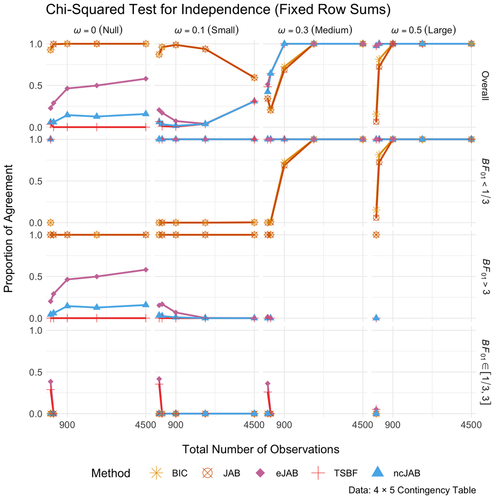

scroll to top

## 5. Table $10\times10$ (`jointMulti`)

Visualization (Fixed Total)

We also conducted a $10\times10$ contingency table analysis.

The extended JAB method may introduce a new issue: its values tend to fall within the inconclusive range when simulated under the null with large dimensions.

However, it effectively resolves the original JAB’s extreme bias towards the null when simulated under the alternative.

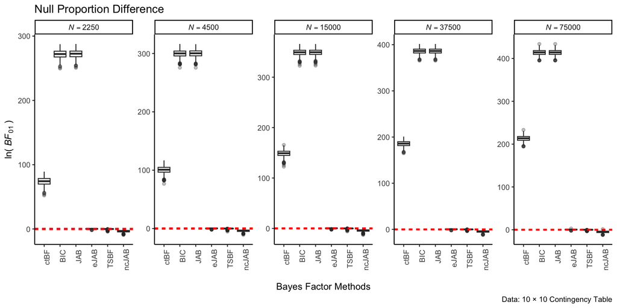

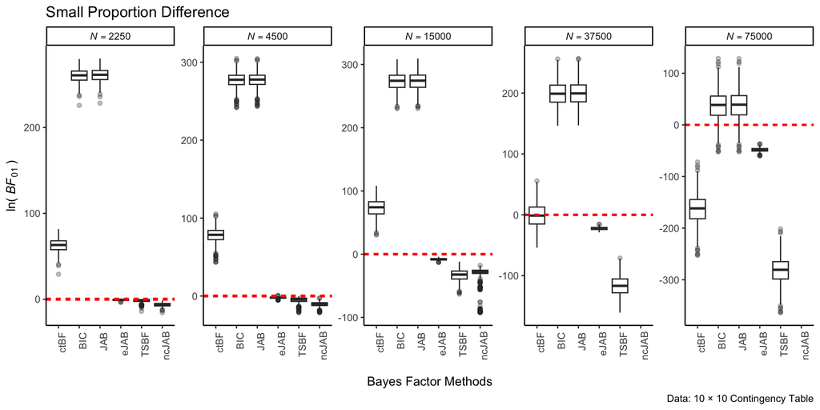

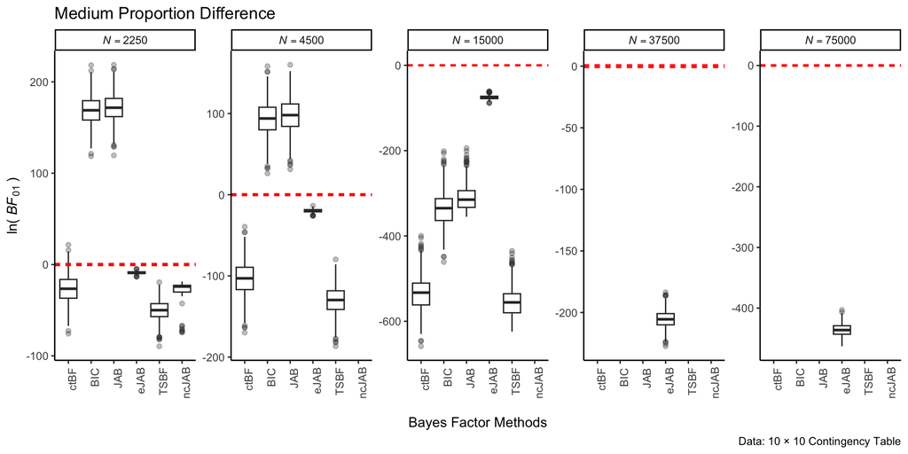

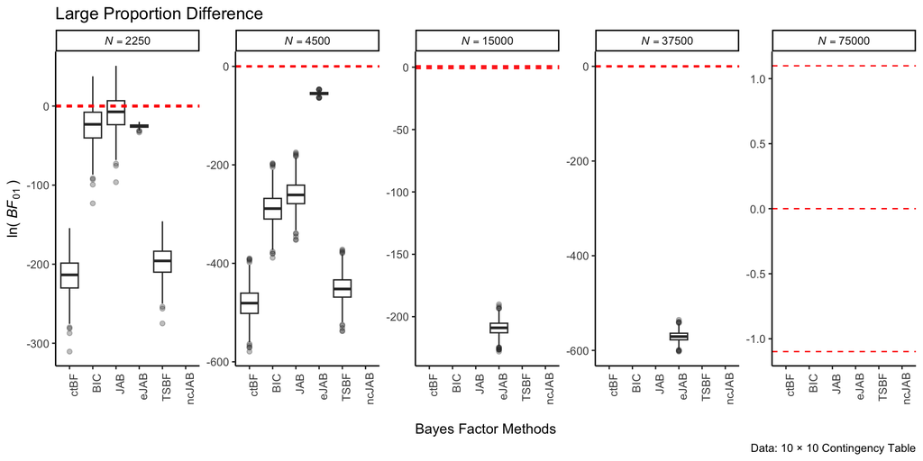

When simulated under the alternative, some methods produce extremely small values supporting the null, which are rounded down to zero. This results in their log values being reported as negative infinity, and consequently, no boxes are shown in the figure.

scroll to top

## 6. Table $2\times2$ (`jointMulti`)

Visualization (Fixed Total)

If the table is $2\times2$ (which corresponds to 1 degree of freedom), there is a point null hypothesis for testing the odds ratio. This scenario is addressed in the original JAB and WAB methods (Wagenmakers, [2022](https://doi.org/10.31234/osf.io/egydq), pp. 28–30; but the definition of effective sample size for logistic regression or contingency tables is more complicated than simply the total number of cases or counts).

In this case, we can also implement the Markov chain Monte Carlo method and the Savage–Dickey density ratio method.

```r
body(computeBFs6) <- bquote({ # re‑assemble a new body
  .(body(computeBFs6))
  WAB01 <- ifelse(pVal <= .5,
                  ifelse(pVal > .1,
                        ifelse(F,
                               4 * pVal^(2/3) * sqrt(total) / 3, # 0.1 < p <= 0.5 (more precise)
                               sqrt(pVal * total)), # 0.1 < p <= 0.5 (simpler)
                        3 * pVal * sqrt(total)), # p <= 0.1
                  pVal^(1/4) * sqrt(total)) # p > 0.5, Eq. 10
  c("ctBF"=BF01, "BIC_approx"=BICB01, "JAB"=JAB01_UI, "eJAB"=JAB01_EXT, "TSBF"=TSBF01, "ncJAB"=JAB01_NCP,
    "WAB"=WAB01) # use the total number of objects
})
```

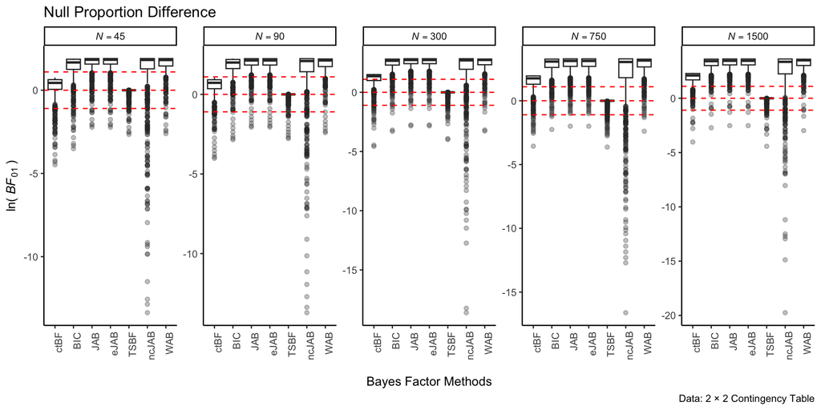

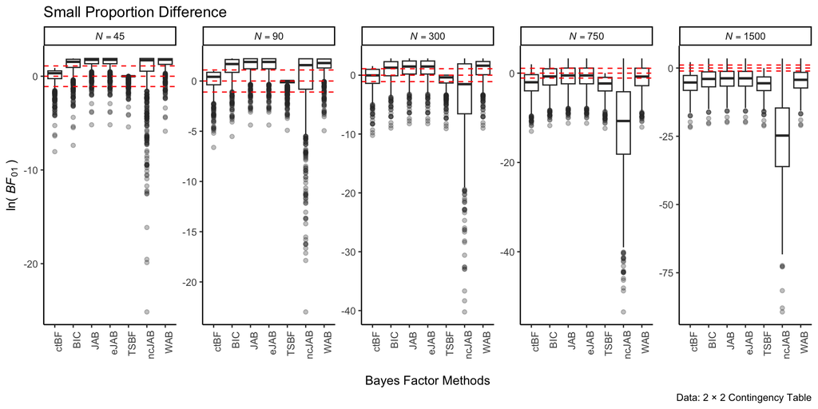

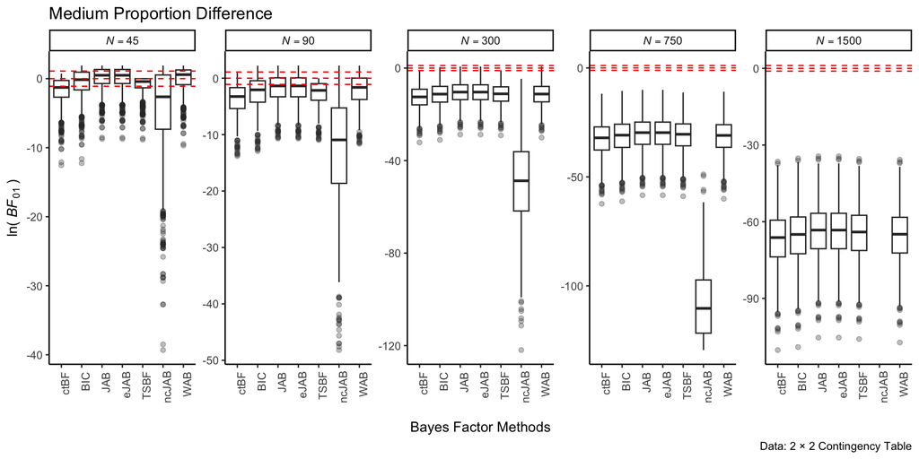

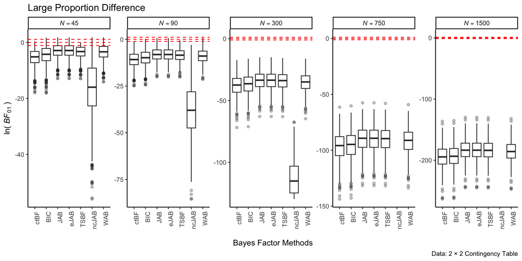

When simulated under the alternative, some methods produce extremely small values supporting the null, which are rounded down to zero. This results in their log values being reported as negative infinity, and consequently, no boxes are shown in the figure.

scroll to top

## 7. eJAB

To test the hypotheses $\mathcal{H}_0:\boldsymbol{\theta}=\boldsymbol{\theta}_0$ versus $\mathcal{H}_1:\boldsymbol{\theta}\neq\boldsymbol{\theta}_0$, we define the extended Jeffreys approximate objective Bayes factor (eJAB) as
$$\begin{equation}
\mathit{eJAB}_{01}=\sqrt{N}\exp\left\{-\frac{1}{2}\frac{N^{1/q}-1}{N^{1/q}}\cdot
Q_{\chi^{2}_{q}}(1-p)\right\},
\end{equation}$$

where $q$ is the size of the parameter vector $\boldsymbol{\theta}$, $N$ is the sample size, $Q_{\chi^{2}_{q}}(\cdot)$ is the quantile function of the chi-squared distribution with $q$ degrees of freedom, and $p$ is the $p$-value from a null-hypothesis significance test. We further define $\mathit{eJAB}_{10}=1\ \!/\ \!\mathit{eJAB}_{01}$.

The sample size $N$ is

- the total number of observations for for $t$-tests, linear regression, logistic regression, one-way ANOVA, and chi-squared tests.
- the number of events for Cox models.
- the number of independent observations for one-way repeated-measures ANOVA (Nathoo & Masson, [2016](https://dx.doi.org/10.1016/j.jmp.2015.03.003)).

The degrees of freedom are

- $q=1$ for $t$-tests, linear regression, logistic regression, and Cox models, where $\mathcal{H}_0$ specifies a point-null hypothesis (Wagenmakers, [2022](https://doi.org/10.31234/osf.io/egydq)).
- $q=I-1$ for one-way ANOVA and one-way repeated-measures ANOVA, where $I$ is the number of conditions.
- $q=(R-1)(C-1)$ for chi-squared tests, where $R$ and $C$ are the numbers of rows and columns, respectively.

Since the Bayes factor is the ratio of the marginal likelihoods of two competing models, $q=p_1-p_0$ also represents the difference in the number of free parameters between the alternative and null models.

For further reading, please visit https://osf.io/qeprj/.

scroll to top

## 8. Debugging

Debugging : There was a bug in plotting the boxplots of the Bayes factors for versions prior to (but not including) **0.9.9000** of this R markdown.

```r
DD <- c("Null"=0, "Small"=1, "Medium"=2, "Large"=3)

myData <- data.frame("Index"=1:100,
                     "dd"=rep(0:3, each=25)) # try also data.table::data.table()

for (dd in DD) {
  subData <- subset(myData, dd==dd)
  print(range(subData$Index))
} # WRONG!
```

```
## [1]   1 100
## [1]   1 100
## [1]   1 100
## [1]   1 100
```

```r
for (i in DD) {
  subData <- subset(myData, dd==i)
  print(range(subData$Index))
} # correct
```

```
## [1]  1 25
## [1] 26 50
## [1] 51 75
## [1]  76 100
```

```r
for (dd in DD) {
  subData <- subset(myData, dd==get("dd", 1L))
  print(range(subData$Index))
} # also works
```

```
## [1]  1 25
## [1] 26 50
## [1] 51 75
## [1]  76 100
```

Discussion: https://stackoverflow.com/q/21658893